# Twitter Analysis using Python

##### Brian Perez and Ashwini Srinivasamohan // Sept 2018 // Montgomery College // Data Science 201

#### Project Summary: The purpose of this project is demonstrate how Python can be used to conduct an analysis of Twitter data using matplotlib, numpy, and pandas. The data set used is based on a previous project done using R, around the frequency of tweets in Venezuela related to the present unstable political situation.

### I. Import matplotlib libraries with aliases mpl and plt. Import numpy for numerical calculations and pandas to read csv file.

```python
import matplotlib as mpl
import matplotlib.pyplot as plt
plt.style.use('classic')
```

```python
#Import numpy to perform calculations using alias, np.

import numpy as np
import pandas as pd
```

### II. Read csv of twitter data into python, subset, and clean-up data

```python
df2 = pd.read_csv('C:/Users/Ash/Desktop/DataSci/2018Proj1/tweets.df.all1.csv', encoding='utf8', parse_dates=['created'] )
#use pandas read_csv. Specify file type using encoding='filetype' and the data type of column 5 ('created') as a date using parse_dates=['colname']
#Source: https://stackoverflow.com/questions/36462852/how-to-read-utf-8-files-with-pandas
```

##### Use split() function to divide the 'statusSource' column into two separate columns - 'SourceInfo' and 'Platform' (Source: https://stackoverflow.com/questions/44206962/splitting-column-value-into-2-new-columns-python-pandas/44207036)

```python
df2['SourceInfo'] = df2['statusSource'].str.split('>', expand=True)[0]
df2['Platform'] = df2['statusSource'].str.split('>', expand=True)[1]
df2
```

|  | Unnamed: 0 | text | favorited | favoriteCount | replyToSN | created | truncated | replyToSID | id | replyToUID | statusSource | screenName | retweetCount | isRetweet | retweeted | longitude | latitude | source_data | SourceInfo | Platform |
| --- | --- | --- | --- | --- | --- | --- | --- | --- | --- | --- | --- | --- | --- | --- | --- | --- | --- | --- | --- | --- |
| 0 | 1 | RT @VatoRegio69: Enmascarados, maduro chingánd... | False | 0 | NaN | 2018-03-09 00:20:18 | False | NaN | 9.719035e+17 | NaN | <a href="http://twitter.com/download/android" ... | Rubielhg | 182 | True | False | NaN | NaN | tweets.df500 | <a href="http://twitter.com/download/android" ... | Twitter for Android</a |
| 1 | 2 | RT @DanielBlancoPz: Smartmatic cerró operacion... | False | 0 | NaN | 2018-03-09 00:20:18 | False | NaN | 9.719035e+17 | NaN | <a href="https://mobile.twitter.com" rel="nofo... | giusyff | 2640 | True | False | NaN | NaN | tweets.df500 | <a href="https://mobile.twitter.com" rel="nofo... | Twitter Lite</a |
| 2 | 3 | Florida aprobó proyecto para prohibir a empres... | False | 0 | NaN | 2018-03-09 00:20:18 | False | NaN | 9.719035e+17 | NaN | <a href="http://publicize.wp.com/" rel="nofoll... | NoticiasVenezue | 0 | False | False | NaN | NaN | tweets.df500 | <a href="http://publicize.wp.com/" rel="nofollow" | WordPress.com</a |
| 3 | 4 | Oposición crea “Frente Amplio Venezuela Libre”... | False | 0 | NaN | 2018-03-09 00:20:18 | False | NaN | 9.719035e+17 | NaN | <a href="http://twitter.com" rel="nofollow">Tw... | sordoiturriza | 0 | False | False | NaN | NaN | tweets.df500 | <a href="http://twitter.com" rel="nofollow" | Twitter Web Client</a |
| 4 | 5 | RT @echalodo: Ahora Petro no sabe como desmarc... | False | 0 | NaN | 2018-03-09 00:20:18 | False | NaN | 9.719035e+17 | NaN | <a href="http://twitter.com/download/iphone" r... | PensarXEscrito | 30 | True | False | NaN | NaN | tweets.df500 | <a href="http://twitter.com/download/iphone" r... | Twitter for iPhone</a |
| 5 | 6 | RT @CarnetDLaPatria: Presidente @NicolasMaduro... | False | 0 | NaN | 2018-03-09 00:20:17 | False | NaN | 9.719035e+17 | NaN | <a href="http://twitter.com/download/android" ... | Conapdis | 3 | True | False | NaN | NaN | tweets.df500 | <a href="http://twitter.com/download/android" ... | Twitter for Android</a |
| 6 | 7 | RT @victoramaya: Lanzamiento del Frente Amplio... | False | 0 | NaN | 2018-03-09 00:20:17 | False | NaN | 9.719035e+17 | NaN | <a href="http://twitter.com/#!/download/ipad" ... | Arkhangell | 457 | True | False | NaN | NaN | tweets.df500 | <a href="http://twitter.com/#!/download/ipad" ... | Twitter for iPad</a |
| 7 | 8 | RT @AndresVelasqz: INOCULTABLE. Ya ni en las F... | False | 0 | NaN | 2018-03-09 00:20:17 | False | NaN | 9.719035e+17 | NaN | <a href="http://twitter.com/download/android" ... | Xiomara13481583 | 1041 | True | False | NaN | NaN | tweets.df500 | <a href="http://twitter.com/download/android" ... | Twitter for Android</a |
| 8 | 9 | RT @dejanirasilveir: #7Mar #URGENTE ESTO ES N ... | False | 0 | NaN | 2018-03-09 00:20:17 | False | NaN | 9.719035e+17 | NaN | <a href="http://twitter.com/download/android" ... | leonmari77 | 275 | True | False | NaN | NaN | tweets.df500 | <a href="http://twitter.com/download/android" ... | Twitter for Android</a |
| 9 | 10 | Embajada de EEUU en Venezuela: Presos político... | False | 0 | NaN | 2018-03-09 00:20:16 | False | NaN | 9.719035e+17 | NaN | <a href="https://ifttt.com" rel="nofollow">IFT... | DElTocuyo | 0 | False | False | NaN | NaN | tweets.df500 | <a href="https://ifttt.com" rel="nofollow" | IFTTT</a |
| 10 | 11 | @mutiroesbibi Venezuela #KCA #PersonalidadeBra... | False | 0 | mutiroesbibi | 2018-03-09 00:20:16 | False | 9.719029e+17 | 9.719035e+17 | 8.917704e+17 | <a href="http://twitter.com/#!/download/ipad" ... | bibimygordafofa | 0 | False | False | NaN | NaN | tweets.df500 | <a href="http://twitter.com/#!/download/ipad" ... | Twitter for iPad</a |
| 11 | 12 | RT @ReporteYa: #8Mar Llovizna en otros países... | False | 0 | NaN | 2018-03-09 00:20:16 | False | NaN | 9.719035e+17 | NaN | <a href="https://mobile.twitter.com" rel="nofo... | jhose268 | 90 | True | False | NaN | NaN | tweets.df500 | <a href="https://mobile.twitter.com" rel="nofo... | Twitter Lite</a |
| 12 | 13 | Feliz día a todas las Mujeres menos a la mama ... | False | 0 | NaN | 2018-03-09 00:20:16 | False | NaN | 9.719035e+17 | NaN | <a href="http://www.facebook.com/twitter" rel=... | Andrewht18 | 0 | False | False | NaN | NaN | tweets.df500 | <a href="http://www.facebook.com/twitter" rel=... | Facebook</a |
| 13 | 14 | RT @JoseAGuerra: La política del #FrenteAmplio... | False | 0 | NaN | 2018-03-09 00:20:15 | False | NaN | 9.719035e+17 | NaN | <a href="https://mobile.twitter.com" rel="nofo... | yubisaygonzale2 | 25 | True | False | NaN | NaN | tweets.df500 | <a href="https://mobile.twitter.com" rel="nofo... | Twitter Lite</a |
| 14 | 15 | RT @AlbertoRavell: La ONU no participará como ... | False | 0 | NaN | 2018-03-09 00:20:15 | False | NaN | 9.719035e+17 | NaN | <a href="http://twitter.com/download/android" ... | lorenadriana1 | 2206 | True | False | NaN | NaN | tweets.df500 | <a href="http://twitter.com/download/android" ... | Twitter for Android</a |
| 15 | 16 | RT @kkatiragladys: Un regimen asesino que apli... | False | 0 | NaN | 2018-03-09 00:20:15 | False | NaN | 9.719035e+17 | NaN | <a href="http://twitter.com" rel="nofollow">Tw... | ERLISSIR | 36 | True | False | NaN | NaN | tweets.df500 | <a href="http://twitter.com" rel="nofollow" | Twitter Web Client</a |
| 16 | 17 | @ANC_ve @ana13944 @Ernesto1931 @robertomalaver... | False | 0 | ANC_ve | 2018-03-09 00:20:15 | True | NaN | 9.719035e+17 | 8.935043e+17 | <a href="https://mobile.twitter.com" rel="nofo... | Kaliwoska1951 | 0 | False | False | NaN | NaN | tweets.df500 | <a href="https://mobile.twitter.com" rel="nofo... | Twitter Lite</a |
| 17 | 18 | RT @fdelrinconCNNE: Feliz día internacional de... | False | 0 | NaN | 2018-03-09 00:20:14 | False | NaN | 9.719035e+17 | NaN | <a href="http://twitter.com/download/android" ... | robertoandery | 175 | True | False | NaN | NaN | tweets.df500 | <a href="http://twitter.com/download/android" ... | Twitter for Android</a |
| 18 | 19 | RT @EstebanDHR: El Frente Amplio de Venezuela ... | False | 0 | NaN | 2018-03-09 00:20:14 | False | NaN | 9.719035e+17 | NaN | <a href="http://twitter.com/download/android" ... | andreinilla | 27 | True | False | NaN | NaN | tweets.df500 | <a href="http://twitter.com/download/android" ... | Twitter for Android</a |
| 19 | 20 | RT @_RoqueCastro: @EAristeguieta Creo que será... | False | 0 | NaN | 2018-03-09 00:20:14 | False | NaN | 9.719035e+17 | NaN | <a href="http://twitter.com/download/android" ... | EWUAO | 11 | True | False | NaN | NaN | tweets.df500 | <a href="http://twitter.com/download/android" ... | Twitter for Android</a |
| 20 | 21 | Curso De Siaho Online, Analiza las condiciones... | False | 0 | NaN | 2018-03-09 00:20:14 | False | NaN | 9.719035e+17 | NaN | <a href="http://www.comerciocenter.net" rel="n... | tesicavenezuela | 0 | False | False | NaN | NaN | tweets.df500 | <a href="http://www.comerciocenter.net" rel="n... | ComercioCenter</a |
| 21 | 22 | Frente Amplio Nacional convocó a protestas - h... | False | 0 | NaN | 2018-03-09 00:20:14 | False | NaN | 9.719035e+17 | NaN | <a href="http://paginadeprueba.com/" rel="nofo... | ContextoDiario | 0 | False | False | NaN | NaN | tweets.df500 | <a href="http://paginadeprueba.com/" rel="nofo... | Publisher192701</a |
| 22 | 23 | RT @VzlaArmySquad: [INF]\n\nVenezuela se encue... | False | 0 | NaN | 2018-03-09 00:20:14 | False | NaN | 9.719035e+17 | NaN | <a href="http://twitter.com/download/android" ... | vjcalv | 53 | True | False | NaN | NaN | tweets.df500 | <a href="http://twitter.com/download/android" ... | Twitter for Android</a |
| 23 | 24 | RT @MariaCorinaYA: Mientras se escucha el cruj... | False | 0 | NaN | 2018-03-09 00:20:14 | False | NaN | 9.719035e+17 | NaN | <a href="http://twitter.com/download/android" ... | verulost | 5862 | True | False | NaN | NaN | tweets.df500 | <a href="http://twitter.com/download/android" ... | Twitter for Android</a |
| 24 | 25 | RT @AnonymousORIE: Venezuela ni de cuarta ni d... | False | 0 | NaN | 2018-03-09 00:20:14 | False | NaN | 9.719034e+17 | NaN | <a href="https://mobile.twitter.com" rel="nofo... | RafaelangeCom6 | 6 | True | False | NaN | NaN | tweets.df500 | <a href="https://mobile.twitter.com" rel="nofo... | Twitter Lite</a |
| 25 | 26 | RT @dahomeyp: ¿Frente Amplio Venezuela Libre?\... | False | 0 | NaN | 2018-03-09 00:20:13 | False | NaN | 9.719034e+17 | NaN | <a href="http://twitter.com/download/android" ... | vs_G8 | 116 | True | False | NaN | NaN | tweets.df500 | <a href="http://twitter.com/download/android" ... | Twitter for Android</a |
| 26 | 27 | RT @Pajaropolitico: -@tatclouthier explicó alg... | False | 0 | NaN | 2018-03-09 00:20:13 | False | NaN | 9.719034e+17 | NaN | <a href="http://twitter.com/download/android" ... | morenodecepa86 | 134 | True | False | NaN | NaN | tweets.df500 | <a href="http://twitter.com/download/android" ... | Twitter for Android</a |
| 27 | 28 | RT @Roraima0: Venezuela no se acostumbrara jam... | False | 0 | NaN | 2018-03-09 00:20:13 | False | NaN | 9.719034e+17 | NaN | <a href="http://twitter.com" rel="nofollow">Tw... | dugartean | 7 | True | False | NaN | NaN | tweets.df500 | <a href="http://twitter.com" rel="nofollow" | Twitter Web Client</a |
| 28 | 29 | RT @AndersonDMG_: Sin ABA CANTV, sin agua, sin... | False | 0 | NaN | 2018-03-09 00:20:13 | False | NaN | 9.719034e+17 | NaN | <a href="http://twitter.com/download/android" ... | Izmarggc | 1 | True | False | NaN | NaN | tweets.df500 | <a href="http://twitter.com/download/android" ... | Twitter for Android</a |
| 29 | 30 | RT @ONU_es: "La situación de los DDHH en Venez... | False | 0 | NaN | 2018-03-09 00:20:13 | False | NaN | 9.719034e+17 | NaN | <a href="http://twitter.com/download/android" ... | CarlosM81949683 | 1320 | True | False | NaN | NaN | tweets.df500 | <a href="http://twitter.com/download/android" ... | Twitter for Android</a |
| ... | ... | ... | ... | ... | ... | ... | ... | ... | ... | ... | ... | ... | ... | ... | ... | ... | ... | ... | ... | ... |
| 33620 | 33621 | RT @valtonyc: Sí, parece ser que la Audiencia ... | False | 0 | NaN | 1521637979 | False | NaN | 9.764466e+17 | NaN | <a href="http://twitter.com/download/android" ... | anna_gra | 7188 | True | False | NaN | NaN | tweets.df3000_3_21 | <a href="http://twitter.com/download/android" ... | Twitter for Android</a |
| 33621 | 33622 | Marqués, juvenil del Barça, de momento dice ‘n... | False | 0 | NaN | 1521637978 | False | NaN | 9.764466e+17 | NaN | <a href="http://www.google.com/" rel="nofollow... | BarcaFans_Col | 0 | False | False | NaN | NaN | tweets.df3000_3_21 | <a href="http://www.google.com/" rel="nofollow" | Google</a |
| 33622 | 33623 | @CaracolRadio En lo particular creo q no hay p... | False | 0 | CaracolRadio | 1521637978 | True | 9.754993e+17 | 9.764466e+17 | 1.923607e+07 | <a href="http://twitter.com/download/iphone" r... | gucabe54200511 | 0 | False | False | NaN | NaN | tweets.df3000_3_21 | <a href="http://twitter.com/download/iphone" r... | Twitter for iPhone</a |
| 33623 | 33624 | RT @iniavenezuela: #18Mar l #EfemérideDeHoy Dí... | False | 0 | NaN | 1521637978 | False | NaN | 9.764466e+17 | NaN | <a href="http://twitter.com" rel="nofollow">Tw... | beyasikbel | 12 | True | False | NaN | NaN | tweets.df3000_3_21 | <a href="http://twitter.com" rel="nofollow" | Twitter Web Client</a |
| 33624 | 33625 | La crisis general de liderazgo en la oposicion... | False | 0 | NaN | 1521637978 | True | NaN | 9.764466e+17 | NaN | <a href="http://twitter.com/download/android" ... | fdaniels69 | 0 | False | False | NaN | NaN | tweets.df3000_3_21 | <a href="http://twitter.com/download/android" ... | Twitter for Android</a |
| 33625 | 33626 | RT @hugorom75: @gercargo @LAPlazasVega MENTIRA... | False | 0 | NaN | 1521637978 | False | NaN | 9.764466e+17 | NaN | <a href="http://twitter.com/download/android" ... | nany_col | 4 | True | False | NaN | NaN | tweets.df3000_3_21 | <a href="http://twitter.com/download/android" ... | Twitter for Android</a |
| 33626 | 33627 | RT @NicolasMaduro: Honor del Pueblo para el ar... | False | 0 | NaN | 1521637977 | False | NaN | 9.764466e+17 | NaN | <a href="http://twitter.com" rel="nofollow">Tw... | sec_infraragua | 865 | True | False | NaN | NaN | tweets.df3000_3_21 | <a href="http://twitter.com" rel="nofollow" | Twitter Web Client</a |
| 33627 | 33628 | RT @CancilleriaVE: Canciller @jaarreaza: En no... | False | 0 | NaN | 1521637977 | False | NaN | 9.764466e+17 | NaN | <a href="http://twitter.com" rel="nofollow">Tw... | Al25noguera | 306 | True | False | NaN | NaN | tweets.df3000_3_21 | <a href="http://twitter.com" rel="nofollow" | Twitter Web Client</a |
| 33628 | 33629 | Todo iba muy bien hasta que te dicen que en Ve... | False | 0 | NaN | 1521637976 | False | NaN | 9.764466e+17 | NaN | <a href="http://twitter.com/download/android" ... | ZahaCassis | 0 | False | False | NaN | NaN | tweets.df3000_3_21 | <a href="http://twitter.com/download/android" ... | Twitter for Android</a |
| 33629 | 33630 | #FelizMiercoles ¡Seguimos haciendo patria! ce... | False | 1 | NaN | 1521637976 | True | NaN | 9.764466e+17 | NaN | <a href="http://twitter.com" rel="nofollow">Tw... | computadorvit | 1 | False | False | NaN | NaN | tweets.df3000_3_21 | <a href="http://twitter.com" rel="nofollow" | Twitter Web Client</a |
| 33630 | 33631 | VENEZUELA ES EL ÚNICO PAIS DEL MUNDO DONDE LOS... | False | 0 | NaN | 1521637976 | False | NaN | 9.764466e+17 | NaN | <a href="http://twitter.com" rel="nofollow">Tw... | paraujo52 | 0 | False | False | NaN | NaN | tweets.df3000_3_21 | <a href="http://twitter.com" rel="nofollow" | Twitter Web Client</a |
| 33631 | 33632 | en venezuela se vive de puta madre me lo ha di... | False | 0 | NaN | 1521637976 | False | NaN | 9.764466e+17 | NaN | <a href="http://cheapbotsdonequick.com" rel="n... | comulerdo_bot | 0 | False | False | NaN | NaN | tweets.df3000_3_21 | <a href="http://cheapbotsdonequick.com" rel="n... | Cheap Bots, Done Quick!</a |
| 33632 | 33633 | RT @maibortpetit: LO ÚLTIMO: General experto e... | False | 0 | NaN | 1521637976 | False | NaN | 9.764466e+17 | NaN | <a href="http://twitter.com/download/android" ... | Esquilaci | 205 | True | False | NaN | NaN | tweets.df3000_3_21 | <a href="http://twitter.com/download/android" ... | Twitter for Android</a |
| 33633 | 33634 | RT @la_iguanatv: "Excluir a Maduro de Cumbre d... | False | 0 | NaN | 1521637975 | False | NaN | 9.764466e+17 | NaN | <a href="http://twitter.com" rel="nofollow">Tw... | BRodriguez2018 | 7 | True | False | NaN | NaN | tweets.df3000_3_21 | <a href="http://twitter.com" rel="nofollow" | Twitter Web Client</a |
| 33634 | 33635 | RT @correoorinoco: #Venezuela : Cuarta mina de... | False | 0 | NaN | 1521637975 | False | NaN | 9.764466e+17 | NaN | <a href="https://mobile.twitter.com" rel="nofo... | tovigo57 | 3 | True | False | NaN | NaN | tweets.df3000_3_21 | <a href="https://mobile.twitter.com" rel="nofo... | Twitter Lite</a |
| 33635 | 33636 | RT @TAMARA_SUJU: #Venezuela amanece hoy, 20M c... | False | 0 | NaN | 1521637975 | False | NaN | 9.764466e+17 | NaN | <a href="http://twitter.com/download/iphone" r... | Gadrisqui | 585 | True | False | NaN | NaN | tweets.df3000_3_21 | <a href="http://twitter.com/download/iphone" r... | Twitter for iPhone</a |
| 33636 | 33637 | RT @ANDRES_CANO42: #Venezuela en el Hospital d... | False | 0 | NaN | 1521637975 | False | NaN | 9.764466e+17 | NaN | <a href="http://twitter.com/download/android" ... | JMMartincal | 635 | True | False | NaN | NaN | tweets.df3000_3_21 | <a href="http://twitter.com/download/android" ... | Twitter for Android</a |
| 33637 | 33638 | RT @NituPerez: Si Maduro nació en Vzla será ve... | False | 0 | NaN | 1521637975 | False | NaN | 9.764466e+17 | NaN | <a href="http://twitter.com/download/iphone" r... | zule2301 | 1596 | True | False | NaN | NaN | tweets.df3000_3_21 | <a href="http://twitter.com/download/iphone" r... | Twitter for iPhone</a |
| 33638 | 33639 | RT @Nuevomedio: Nos tienen entretenidos evitan... | False | 0 | NaN | 1521637975 | False | NaN | 9.764466e+17 | NaN | <a href="http://twitter.com/download/android" ... | Nuevomedio | 2 | True | False | NaN | NaN | tweets.df3000_3_21 | <a href="http://twitter.com/download/android" ... | Twitter for Android</a |
| 33639 | 33640 | RT @ErrazurizL: Así estuve por cerca de 2 hora... | False | 0 | NaN | 1521637974 | False | NaN | 9.764466e+17 | NaN | <a href="http://twitter.com/download/android" ... | Andresmarin08 | 41 | True | False | NaN | NaN | tweets.df3000_3_21 | <a href="http://twitter.com/download/android" ... | Twitter for Android</a |
| 33640 | 33641 | Epa @NicolasMaduro! Venezuela hoy: Escuelas, l... | False | 0 | NaN | 1521637974 | True | NaN | 9.764466e+17 | NaN | <a href="http://twitter.com" rel="nofollow">Tw... | hectorperez201 | 0 | False | False | NaN | NaN | tweets.df3000_3_21 | <a href="http://twitter.com" rel="nofollow" | Twitter Web Client</a |
| 33641 | 33642 | RT @NDtitulares: Eurocámara: Venezuela tiene u... | False | 0 | NaN | 1521637974 | False | NaN | 9.764466e+17 | NaN | <a href="http://twitter.com/download/android" ... | UnionCiudadanaV | 4 | True | False | NaN | NaN | tweets.df3000_3_21 | <a href="http://twitter.com/download/android" ... | Twitter for Android</a |
| 33642 | 33643 | RT @elcedetueme: Diosdado: "mas nunca volverán... | False | 0 | NaN | 1521637973 | False | NaN | 9.764466e+17 | NaN | <a href="http://twitter.com/download/iphone" r... | ymrdiaz | 3426 | True | False | NaN | NaN | tweets.df3000_3_21 | <a href="http://twitter.com/download/iphone" r... | Twitter for iPhone</a |
| 33643 | 33644 | @NaranjaRA @armaspadron Si maldito cdtm pagará... | False | 1 | NaranjaRA | 1521637973 | True | 9.764233e+17 | 9.764466e+17 | 1.424057e+09 | <a href="http://twitter.com/download/android" ... | rochoa10 | 0 | False | False | NaN | NaN | tweets.df3000_3_21 | <a href="http://twitter.com/download/android" ... | Twitter for Android</a |
| 33644 | 33645 | RT @BeticaMunozPogo: Estamos en una crisis hum... | False | 0 | NaN | 1521637973 | False | NaN | 9.764466e+17 | NaN | <a href="http://twitter.com/download/android" ... | junior04082012 | 625 | True | False | NaN | NaN | tweets.df3000_3_21 | <a href="http://twitter.com/download/android" ... | Twitter for Android</a |
| 33645 | 33646 | RT @IgnacioSerrano: Tiemblo cada vez que anunc... | False | 0 | NaN | 1521637973 | False | NaN | 9.764465e+17 | NaN | <a href="http://twitter.com" rel="nofollow">Tw... | TurboLove04 | 18 | True | False | NaN | NaN | tweets.df3000_3_21 | <a href="http://twitter.com" rel="nofollow" | Twitter Web Client</a |
| 33646 | 33647 | RT @JuventudesVP: Usar un megáfono y exigir li... | False | 0 | NaN | 1521637973 | False | NaN | 9.764465e+17 | NaN | <a href="http://twitter.com/download/android" ... | jvpa_valencia | 8 | True | False | NaN | NaN | tweets.df3000_3_21 | <a href="http://twitter.com/download/android" ... | Twitter for Android</a |
| 33647 | 33648 | RT @teleSURtv: #Venezuela posee la cuarta mina... | False | 0 | NaN | 1521637973 | False | NaN | 9.764465e+17 | NaN | <a href="http://twitter.com/download/android" ... | byanjama | 34 | True | False | NaN | NaN | tweets.df3000_3_21 | <a href="http://twitter.com/download/android" ... | Twitter for Android</a |
| 33648 | 33649 | RT @InfobaeAmerica: La sombra de Rusia detrás ... | False | 0 | NaN | 1521637973 | False | NaN | 9.764465e+17 | NaN | <a href="http://twitter.com/download/iphone" r... | eddiedavilab | 7 | True | False | NaN | NaN | tweets.df3000_3_21 | <a href="http://twitter.com/download/iphone" r... | Twitter for iPhone</a |
| 33649 | 33650 | RT @GenPenaloza: EL PADRINO esta tan loco como... | False | 0 | NaN | 1521637973 | False | NaN | 9.764465e+17 | NaN | <a href="http://twitter.com/download/android" ... | joseloramo | 1405 | True | False | NaN | NaN | tweets.df3000_3_21 | <a href="http://twitter.com/download/android" ... | Twitter for Android</a |

33650 rows × 20 columns

##### Remove </a delimiter from all rows in the 'Platform' column, to further clean-up data. (Source: https://stackoverflow.com/questions/40705480/python-pandas-remove-everything-after-a-delimiter-in-a-string)

```python
df2['Platform'] = df2['Platform'].str.split('<').str[0]
df2.head()
```

|  | Unnamed: 0 | text | favorited | favoriteCount | replyToSN | created | truncated | replyToSID | id | replyToUID | statusSource | screenName | retweetCount | isRetweet | retweeted | longitude | latitude | source_data | SourceInfo | Platform |
| --- | --- | --- | --- | --- | --- | --- | --- | --- | --- | --- | --- | --- | --- | --- | --- | --- | --- | --- | --- | --- |
| 0 | 1 | RT @VatoRegio69: Enmascarados, maduro chingánd... | False | 0 | NaN | 2018-03-09 00:20:18 | False | NaN | 9.719035e+17 | NaN | <a href="http://twitter.com/download/android" ... | Rubielhg | 182 | True | False | NaN | NaN | tweets.df500 | <a href="http://twitter.com/download/android" ... | Twitter for Android |
| 1 | 2 | RT @DanielBlancoPz: Smartmatic cerró operacion... | False | 0 | NaN | 2018-03-09 00:20:18 | False | NaN | 9.719035e+17 | NaN | <a href="https://mobile.twitter.com" rel="nofo... | giusyff | 2640 | True | False | NaN | NaN | tweets.df500 | <a href="https://mobile.twitter.com" rel="nofo... | Twitter Lite |
| 2 | 3 | Florida aprobó proyecto para prohibir a empres... | False | 0 | NaN | 2018-03-09 00:20:18 | False | NaN | 9.719035e+17 | NaN | <a href="http://publicize.wp.com/" rel="nofoll... | NoticiasVenezue | 0 | False | False | NaN | NaN | tweets.df500 | <a href="http://publicize.wp.com/" rel="nofollow" | WordPress.com |
| 3 | 4 | Oposición crea “Frente Amplio Venezuela Libre”... | False | 0 | NaN | 2018-03-09 00:20:18 | False | NaN | 9.719035e+17 | NaN | <a href="http://twitter.com" rel="nofollow">Tw... | sordoiturriza | 0 | False | False | NaN | NaN | tweets.df500 | <a href="http://twitter.com" rel="nofollow" | Twitter Web Client |
| 4 | 5 | RT @echalodo: Ahora Petro no sabe como desmarc... | False | 0 | NaN | 2018-03-09 00:20:18 | False | NaN | 9.719035e+17 | NaN | <a href="http://twitter.com/download/iphone" r... | PensarXEscrito | 30 | True | False | NaN | NaN | tweets.df500 | <a href="http://twitter.com/download/iphone" r... | Twitter for iPhone |

### III. Create Pie Chart and Bar Plot of Most-Used Twitter Platforms

#### In order to create the charts, a data frame of only the device platforms and the frequency of their use needs to be created, with another column added calculating the proportion.

##### Use .value_counts() function. Use .reset_index() to ensure that the first column is 'Platform' and the second 'Freq.' Below, the first five rows (top 5 platforms used) are printed. (Source: DataCamp)

```python
platfreq = df2['Platform'].value_counts()

dfplatfreq = platfreq.to_frame().reset_index()

dfplatfreq = dfplatfreq.rename(columns= {'index': 'Platform','Platform':'Freq'})

dfplatfreq=dfplatfreq.assign(Prop=dfplatfreq.Freq*100.00/dfplatfreq.Freq.sum())

dfplatfreq.head()
```

|  | Platform | Freq | Prop |
| --- | --- | --- | --- |
| 0 | Twitter for Android | 15544 | 46.193165 |
| 1 | Twitter Web Client | 7741 | 23.004458 |
| 2 | Twitter for iPhone | 4686 | 13.925706 |
| 3 | Twitter Lite | 1279 | 3.800892 |
| 4 | TweetDeck | 833 | 2.475483 |

##### Aggregate anytything below 1% as 'Other' category

```python
t1=dfplatfreq.query('Prop > 1')
t2=dfplatfreq.query('Prop < 1')

sumfreq = t2.Freq.sum()
sumprop = t2.Prop.sum()

t3 = pd.DataFrame({'Platform':'Other','Freq':sumfreq,'Prop':sumprop},index=[0])

#t4 = (pd.concat([t1, t3]))

t5 = t1.append(pd.DataFrame(data=t3),ignore_index=True)

t5
```

|  | Platform | Freq | Prop |
| --- | --- | --- | --- |
| 0 | Twitter for Android | 15544 | 46.193165 |
| 1 | Twitter Web Client | 7741 | 23.004458 |
| 2 | Twitter for iPhone | 4686 | 13.925706 |
| 3 | Twitter Lite | 1279 | 3.800892 |
| 4 | TweetDeck | 833 | 2.475483 |
| 5 | Twitter for iPad | 591 | 1.756315 |
| 6 | Other | 2976 | 8.843982 |

##### Bar Plot: Create bar plot using the counts.plot(kind='bar') function

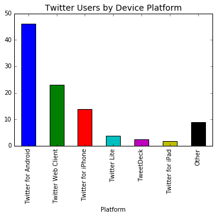

```python
t5.plot(x= 'Platform', y = 'Prop', kind='bar', legend=None)
plt.title('Twitter Users by Device Platform', fontsize=14)

plt.show()
```

##### Pie Chart: Create pie chart of the top device platforms used

```
 [Text(0.131241,1.09214,'Twitter for Android'),
  Text(-0.973903,-0.511384,'Twitter Web Client'),
  Text(0.0801352,-1.09708,'Twitter for iPhone'),
  Text(0.647892,-0.888952,'Twitter Lite'),
  Text(0.809487,-0.744803,'TweetDeck'),
  Text(0.901071,-0.630929,'Twitter for iPad'),
  Text(1.05781,-0.301709,'Other')],
 [Text(0.0715862,0.595714,'46.2%'),
  Text(-0.53122,-0.278937,'23.0%'),
  Text(0.0437101,-0.598406,'13.9%'),
  Text(0.353396,-0.484883,'3.8%'),
  Text(0.441538,-0.406256,'2.5%'),
  Text(0.491493,-0.344143,'1.8%'),
  Text(0.57699,-0.164569,'8.8%')])
```

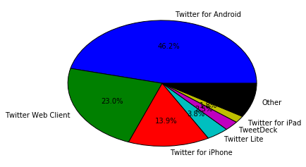

```python
#t5.plot(x= 'Platform', y = 'Prop', kind='pie', legend=None)
#plt.title('Twitter Users by Device Platform', fontsize=14)

plt.pie(
    t5['Freq'],
    labels=t5['Platform'],
    autopct='%1.1f%%',
)
```